# Handeling and exploring data in the tidyverse

## About me: Jens Roeser

- early career researchfellow @ psychology department (Nottingham Trent University)
- theory: psycholinguistics; language production / comprehension / acquisition (e.g. Roeser, Torrance, and Baguley 2019)
- methods: Bayesian modelling (talk to me about mixture models, Roeser et al. 2021) in Stan; keystroke logging; eyetracking
- teaching: statistics – R of course (`psyntur`, Andrews and Roeser 2021); cognitive psychology; language acquisition
- twitter: https://twitter.com/jens_roeser

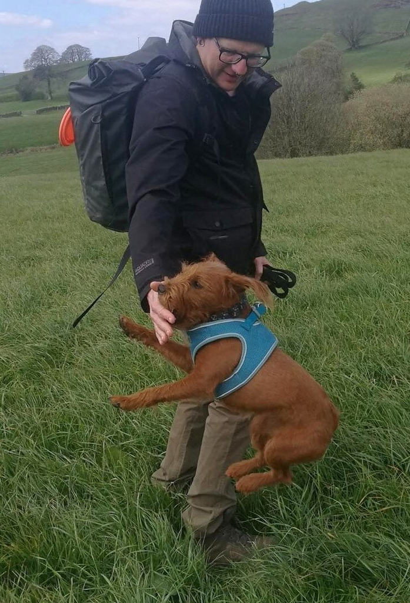

## Outline

- Data viz with `ggplot2`
- Data wrangling with `tidyverse`
- Lots of hands-on exercises

## Why should I care?

Why using R (or code in general) to handle data?

*What do you think?*

## Why should I care?

Why using R (or code in general) to handle data?

- > 70% to 80% of data analysis is data wrangling
- Open source: R is and always will be free
- Large community of friendly peer support
- Reproducibility: publish your code and look at code of other researchers
- Flexibility: different ways of looking at data
- Quickly growing number of available add-ons
- Faster than manual data processing
- Processing of **large** data sets
- Reduce manual work
- Reduce human error

## Rules!

- Never change your data manually; document everything in code.
  - Retrospective amendments made easy
  - Documentation / reproducibility
- Organized working environment
  - `.Rproj` with one director per project with sub-directories for scripts, data, plots, etc
  - Short scripts: less code with one clear purpose is always better (test is: does the name of your script suggest a specific or general purpose?)
- Comment your code (`# Ceci n'est pas un comment!`)
- If possible, use `tidyverse` instead of base R.

## Recommended reading

- *R for Data Science* by Wickham and Grolemund
- This link r4ds.had.co.nz/

[figure not shown]

## Download repository

- Download: https://github.com/jensroes/ljm-r-workshop
- Click on: `Code` > `Download ZIP` > unzip directory on your machine.
- Open project by double clicking on `ljm-r-workshop.Rproj`
- `viz/exercises/`: exercises associated with each topic
- `data/`: scripts read data from here
- `viz/slides.Rmd`: these slides in R markdown format (`.html` format provided as well)

## Example data set: Blomkvist et al. (2017)

[figure not shown]

[figure not shown]

[figure not shown]

[figure not shown]

## Example data set: Blomkvist et al. (2017)

```r
blomkvist <- read_csv("../data/blomkvist.csv")
glimpse(blomkvist)
```

```
Rows: 267
Columns: 10
$ id         <dbl> 1, 2, 3, 4, 5, 6, 7, 8, 9, 10, 11, 12, …
$ sex        <chr> "male", "female", "female", "female", "…
$ age        <dbl> 84, 37, 62, 85, 73, 65, 30, 49, 83, 58,…
$ medicine   <dbl> 8, 1, 0, 4, 5, 0, 0, 0, 11, 0, 0, 4, 3,…
$ meds_cat   <chr> "a lot", "little", "none", "few", "a lo…
$ smoker     <chr> "former", "no", "yes", "former", "forme…
$ rt_hand_d  <dbl> 702, 471, 639, 708, 607, 542, 571, 509,…
$ rt_hand_nd <dbl> 780, 497, 638, 639, 652, 499, 527, 547,…
$ rt_foot_d  <dbl> 1009, 738, 878, 902, 923, 687, 778, 743…
$ rt_foot_nd <dbl> 963, 692, 786, 1374, 805, 600, 750, 797…
```

- Average reaction time (`rt`) of dominant (`_d`) or non-dominant (`_nd`) `hand` or `foot` in msecs
- `medicine`: number of drugs used daily

## References

Andrews, Mark, and Jens Roeser. 2021. *Psyntur: Helper Tools for Teaching Statistical Data Analysis*. https://CRAN.R-project.org/package=psyntur.

Blomkvist, Andreas W., Fredrik Eika, Martin T. Rahbek, Karin D. Eikhof, Mette D. Hansen, Malene Søndergaard, Jesper Ryg, Stig Andersen, and Martin G. Jørgensen. 2017. “Reference Data on Reaction Time and Aging Using the Nintendo Wii Balance Board: A Cross-Sectional Study of 354 Subjects from 20 to 99 Years of Age.” *PLoS One* 12 (12): e0189598.

Roeser, Jens, Sven De Maeyer, Mariëlle Leijten, and Luuk Van Waes. 2021. “Modelling Typing Disfluencies as Finite Mixture Process.” *Reading and Writing*, 1–26.

Roeser, Jens, Mark Torrance, and Thom Baguley. 2019. “Advance Planning in Written and Spoken Sentence Production.” *Journal of Experimental Psychology: Learning, Memory, and Cognition* 45 (11): 1983–2009.